# Project: Investigating Causes of Missed Apointments

- Introduction
- Data Wrangling
- Feature Engineering
- Exploratory Data Analysis
- Conclusions

## Introduction

In this project we will be looking at the No-show Appointments dataset, a collection of over 100,000 medical appointments in Brazil, using a variety of tools including: pandas, numpy, and matplotlib. This dataset includes information on the loction of the hospital, the day the appointment was sheduled, the day the appointment was held, whether the family qualified for government assistance, and whether the patient showed up to their appointment, among other features. The purpose of this investigation is to determine what factors were most impactful in a patient not appearing for their appointment, in order to gain insight into how to ensure patients show up and recieve their medical care.

```python
import pandas as pd
import numpy as np
import matplotlib.pyplot as plt
import seaborn as sns
%matplotlib inline
```

## Data Wrangling

### General Properties

This dataset is made up of 110527 rows of data across 14 columns: `PatientId`, `AppointmentID`, `Gender`, `ScheduledDay`, `AppointmentDay`, `Age`, `Neighbourhood`, `Scholarship`, `Hipertension`, `Diabetes`, `Alcoholism`, `Handcap`, `SMS_received`, and `No-show`

```python
df = pd.read_csv("./noshowappointments-kagglev2-may-2016.csv")
df.head()
```

|  | PatientId | AppointmentID | Gender | ScheduledDay | AppointmentDay | Age | Neighbourhood | Scholarship | Hipertension | Diabetes | Alcoholism | Handcap | SMS_received | No-show |
| --- | --- | --- | --- | --- | --- | --- | --- | --- | --- | --- | --- | --- | --- | --- |
| 0 | 2.987250e+13 | 5642903 | F | 2016-04-29T18:38:08Z | 2016-04-29T00:00:00Z | 62 | JARDIM DA PENHA | 0 | 1 | 0 | 0 | 0 | 0 | No |
| 1 | 5.589978e+14 | 5642503 | M | 2016-04-29T16:08:27Z | 2016-04-29T00:00:00Z | 56 | JARDIM DA PENHA | 0 | 0 | 0 | 0 | 0 | 0 | No |
| 2 | 4.262962e+12 | 5642549 | F | 2016-04-29T16:19:04Z | 2016-04-29T00:00:00Z | 62 | MATA DA PRAIA | 0 | 0 | 0 | 0 | 0 | 0 | No |
| 3 | 8.679512e+11 | 5642828 | F | 2016-04-29T17:29:31Z | 2016-04-29T00:00:00Z | 8 | PONTAL DE CAMBURI | 0 | 0 | 0 | 0 | 0 | 0 | No |
| 4 | 8.841186e+12 | 5642494 | F | 2016-04-29T16:07:23Z | 2016-04-29T00:00:00Z | 56 | JARDIM DA PENHA | 0 | 1 | 1 | 0 | 0 | 0 | No |

```python
df.shape
```

```
(110527, 14)
```

### Data Cleaning

In order to ensure we have complete information on all of the appointments, we should begin by checking for null values and exclude those from our dataset

```python
df.isna().sum()
```

```
PatientId         0
AppointmentID     0
Gender            0
ScheduledDay      0
AppointmentDay    0
Age               0
Neighbourhood     0
Scholarship       0
Hipertension      0
Diabetes          0
Alcoholism        0
Handcap           0
SMS_received      0
No-show           0
dtype: int64
```

Now that we have ensured none of the rows are missing data, we can check for and drop duplicates

```python
df.duplicated().sum()
```

```
0
```

Now that we have ensured none of the rows are duplicated, we can check to ensure that none of the columns have data which doesn't fit our expected schema.

```python
for col in df.columns:
  print(f"Number of unique values in {col}: {len(df[col].unique())}")
```

```
Number of unique values in PatientId: 62299
Number of unique values in AppointmentID: 110527
Number of unique values in Gender: 2
Number of unique values in ScheduledDay: 103549
Number of unique values in AppointmentDay: 27
Number of unique values in Age: 104
Number of unique values in Neighbourhood: 81
Number of unique values in Scholarship: 2
Number of unique values in Hipertension: 2
Number of unique values in Diabetes: 2
Number of unique values in Alcoholism: 2
Number of unique values in Handcap: 5
Number of unique values in SMS_received: 2
Number of unique values in No-show: 2
```

There are some suprising values in the data, such as `Handcap` having 5 values, where it is intended to be a boolean value, `Neighbourhood` having 81, and `Age` having 104. Lets investigate these more closely.

```python
uniq_handcap = df["Handcap"].unique()
uniq_handcap
```

```
array([0, 1, 2, 3, 4], dtype=int64)
```

```python
def print_uniq_hancap_counts():
  for v in uniq_handcap:
    print(f"Number of rows with Handcap = {v} : {df[df['Handcap'] == v].shape[0]}")
print_uniq_hancap_counts()
```

```
Number of rows with Handcap = 0 : 108286
Number of rows with Handcap = 1 : 2042
Number of rows with Handcap = 2 : 183
Number of rows with Handcap = 3 : 13
Number of rows with Handcap = 4 : 3
```

It appears that the `Handcap` feature was used as a scale of the severity of the handicap, rather than a boolean as defined by our [data dictionary](https://www.kaggle.com/datasets/joniarroba/noshowappointments). We will change it to match the data dictionary by converting all values >= 1 to 1

```python
df["Handcap"] = df["Handcap"].apply(lambda x: int(x >= 1))
print_uniq_hancap_counts()
```

```
Number of rows with Handcap = 0 : 108286
Number of rows with Handcap = 1 : 2241
Number of rows with Handcap = 2 : 0
Number of rows with Handcap = 3 : 0
Number of rows with Handcap = 4 : 0
```

```python
df["Neighbourhood"].unique()
```

```
array(['JARDIM DA PENHA', 'MATA DA PRAIA', 'PONTAL DE CAMBURI',
       'REPÚBLICA', 'GOIABEIRAS', 'ANDORINHAS', 'CONQUISTA',
       'NOVA PALESTINA', 'DA PENHA', 'TABUAZEIRO', 'BENTO FERREIRA',
       'SÃO PEDRO', 'SANTA MARTHA', 'SÃO CRISTÓVÃO', 'MARUÍPE',
       'GRANDE VITÓRIA', 'SÃO BENEDITO', 'ILHA DAS CAIEIRAS',
       'SANTO ANDRÉ', 'SOLON BORGES', 'BONFIM', 'JARDIM CAMBURI',
       'MARIA ORTIZ', 'JABOUR', 'ANTÔNIO HONÓRIO', 'RESISTÊNCIA',
       'ILHA DE SANTA MARIA', 'JUCUTUQUARA', 'MONTE BELO',
       'MÁRIO CYPRESTE', 'SANTO ANTÔNIO', 'BELA VISTA', 'PRAIA DO SUÁ',
       'SANTA HELENA', 'ITARARÉ', 'INHANGUETÁ', 'UNIVERSITÁRIO',
       'SÃO JOSÉ', 'REDENÇÃO', 'SANTA CLARA', 'CENTRO', 'PARQUE MOSCOSO',
       'DO MOSCOSO', 'SANTOS DUMONT', 'CARATOÍRA', 'ARIOVALDO FAVALESSA',
       'ILHA DO FRADE', 'GURIGICA', 'JOANA D´ARC', 'CONSOLAÇÃO',
       'PRAIA DO CANTO', 'BOA VISTA', 'MORADA DE CAMBURI', 'SANTA LUÍZA',
       'SANTA LÚCIA', 'BARRO VERMELHO', 'ESTRELINHA', 'FORTE SÃO JOÃO',
       'FONTE GRANDE', 'ENSEADA DO SUÁ', 'SANTOS REIS', 'PIEDADE',
       'JESUS DE NAZARETH', 'SANTA TEREZA', 'CRUZAMENTO',
       'ILHA DO PRÍNCIPE', 'ROMÃO', 'COMDUSA', 'SANTA CECÍLIA',
       'VILA RUBIM', 'DE LOURDES', 'DO QUADRO', 'DO CABRAL', 'HORTO',
       'SEGURANÇA DO LAR', 'ILHA DO BOI', 'FRADINHOS', 'NAZARETH',
       'AEROPORTO', 'ILHAS OCEÂNICAS DE TRINDADE', 'PARQUE INDUSTRIAL'],
      dtype=object)
```

It appears there are 81 different values for `Neighbourhood`. No changes are needed.

```python
df["Age"].unique()
```

```
array([ 62,  56,   8,  76,  23,  39,  21,  19,  30,  29,  22,  28,  54,
        15,  50,  40,  46,   4,  13,  65,  45,  51,  32,  12,  61,  38,
        79,  18,  63,  64,  85,  59,  55,  71,  49,  78,  31,  58,  27,
         6,   2,  11,   7,   0,   3,   1,  69,  68,  60,  67,  36,  10,
        35,  20,  26,  34,  33,  16,  42,   5,  47,  17,  41,  44,  37,
        24,  66,  77,  81,  70,  53,  75,  73,  52,  74,  43,  89,  57,
        14,   9,  48,  83,  72,  25,  80,  87,  88,  84,  82,  90,  94,
        86,  91,  98,  92,  96,  93,  95,  97, 102, 115, 100,  99,  -1],
      dtype=int64)
```

The -1 value of some of the data leads me to believe that this is missing data, and while ages of 115 seem unlikely, there are people in Brazil who claim to be 122 years old, so not impossible, but still deserving of investigation.

```python
df[df["Age"] == -1]
```

|  | PatientId | AppointmentID | Gender | ScheduledDay | AppointmentDay | Age | Neighbourhood | Scholarship | Hipertension | Diabetes | Alcoholism | Handcap | SMS_received | No-show |
| --- | --- | --- | --- | --- | --- | --- | --- | --- | --- | --- | --- | --- | --- | --- |
| 99832 | 4.659432e+14 | 5775010 | F | 2016-06-06T08:58:13Z | 2016-06-06T00:00:00Z | -1 | ROMÃO | 0 | 0 | 0 | 0 | 0 | 0 | No |

Only one record, so we will start by looking up the `PatientId` and seeing if we can use that to determine their age, if not we will drop this record.

```python
pid = df[df["Age"] == -1]["PatientId"].max()
pid
```

```
465943158731293.0
```

```python
df[df["PatientId"] == pid]
```

|  | PatientId | AppointmentID | Gender | ScheduledDay | AppointmentDay | Age | Neighbourhood | Scholarship | Hipertension | Diabetes | Alcoholism | Handcap | SMS_received | No-show |
| --- | --- | --- | --- | --- | --- | --- | --- | --- | --- | --- | --- | --- | --- | --- |
| 99832 | 4.659432e+14 | 5775010 | F | 2016-06-06T08:58:13Z | 2016-06-06T00:00:00Z | -1 | ROMÃO | 0 | 0 | 0 | 0 | 0 | 0 | No |

```python
try:
  df = df.drop(index = df[df["PatientId"] == pid].index)
except:
  pass
df[df["PatientId"] == pid]
```

|  | PatientId | AppointmentID | Gender | ScheduledDay | AppointmentDay | Age | Neighbourhood | Scholarship | Hipertension | Diabetes | Alcoholism | Handcap | SMS_received | No-show |
| --- | --- | --- | --- | --- | --- | --- | --- | --- | --- | --- | --- | --- | --- | --- |

Now that the -1 value has been dropped, lets investigate the 115 value

```python
df[df["Age"] == 115]
```

|  | PatientId | AppointmentID | Gender | ScheduledDay | AppointmentDay | Age | Neighbourhood | Scholarship | Hipertension | Diabetes | Alcoholism | Handcap | SMS_received | No-show |
| --- | --- | --- | --- | --- | --- | --- | --- | --- | --- | --- | --- | --- | --- | --- |
| 63912 | 3.196321e+13 | 5700278 | F | 2016-05-16T09:17:44Z | 2016-05-19T00:00:00Z | 115 | ANDORINHAS | 0 | 0 | 0 | 0 | 1 | 0 | Yes |
| 63915 | 3.196321e+13 | 5700279 | F | 2016-05-16T09:17:44Z | 2016-05-19T00:00:00Z | 115 | ANDORINHAS | 0 | 0 | 0 | 0 | 1 | 0 | Yes |
| 68127 | 3.196321e+13 | 5562812 | F | 2016-04-08T14:29:17Z | 2016-05-16T00:00:00Z | 115 | ANDORINHAS | 0 | 0 | 0 | 0 | 1 | 0 | Yes |
| 76284 | 3.196321e+13 | 5744037 | F | 2016-05-30T09:44:51Z | 2016-05-30T00:00:00Z | 115 | ANDORINHAS | 0 | 0 | 0 | 0 | 1 | 0 | No |
| 97666 | 7.482346e+14 | 5717451 | F | 2016-05-19T07:57:56Z | 2016-06-03T00:00:00Z | 115 | SÃO JOSÉ | 0 | 1 | 0 | 0 | 0 | 1 | No |

```python
import datetime
def obj_to_datetime(str):
  return datetime.datetime.strptime(str,"%Y-%m-%dT%H:%M:%SZ")

df["AppointmentDay"] = df["AppointmentDay"].apply(lambda x:obj_to_datetime(x).date())
len(df["AppointmentDay"].unique())
```

```
27
```

Cool now this will be much easier to handle as it is saved as a Date, we should also conver `ScheduledDay` to a Date

```python
df["ScheduledDay"] = df["ScheduledDay"].apply(lambda x:obj_to_datetime(x).date())
df.info()
```

```
<class 'pandas.core.frame.DataFrame'>
Int64Index: 110526 entries, 0 to 110526
Data columns (total 14 columns):
 #   Column          Non-Null Count   Dtype
---  ------          --------------   -----
 0   PatientId       110526 non-null  float64
 1   AppointmentID   110526 non-null  int64
 2   Gender          110526 non-null  object
 3   ScheduledDay    110526 non-null  object
 4   AppointmentDay  110526 non-null  object
 5   Age             110526 non-null  int64
 6   Neighbourhood   110526 non-null  object
 7   Scholarship     110526 non-null  int64
 8   Hipertension    110526 non-null  int64
 9   Diabetes        110526 non-null  int64
 10  Alcoholism      110526 non-null  int64
 11  Handcap         110526 non-null  int64
 12  SMS_received    110526 non-null  int64
 13  No-show         110526 non-null  object
dtypes: float64(1), int64(8), object(5)
memory usage: 12.6+ MB
```

Now that we can compare dates easily, we should run a check to ensure that the `ScheduledDay` is less than the `AppointmentDay`

```python
df[df["ScheduledDay"] > df["AppointmentDay"]]
```

|  | PatientId | AppointmentID | Gender | ScheduledDay | AppointmentDay | Age | Neighbourhood | Scholarship | Hipertension | Diabetes | Alcoholism | Handcap | SMS_received | No-show |
| --- | --- | --- | --- | --- | --- | --- | --- | --- | --- | --- | --- | --- | --- | --- |
| 27033 | 7.839273e+12 | 5679978 | M | 2016-05-10 | 2016-05-09 | 38 | RESISTÊNCIA | 0 | 0 | 0 | 0 | 1 | 0 | Yes |
| 55226 | 7.896294e+12 | 5715660 | F | 2016-05-18 | 2016-05-17 | 19 | SANTO ANTÔNIO | 0 | 0 | 0 | 0 | 1 | 0 | Yes |
| 64175 | 2.425226e+13 | 5664962 | F | 2016-05-05 | 2016-05-04 | 22 | CONSOLAÇÃO | 0 | 0 | 0 | 0 | 0 | 0 | Yes |
| 71533 | 9.982316e+14 | 5686628 | F | 2016-05-11 | 2016-05-05 | 81 | SANTO ANTÔNIO | 0 | 0 | 0 | 0 | 0 | 0 | Yes |
| 72362 | 3.787482e+12 | 5655637 | M | 2016-05-04 | 2016-05-03 | 7 | TABUAZEIRO | 0 | 0 | 0 | 0 | 0 | 0 | Yes |

There are 5 values that have inconsistant dates, so lets drop these.

```python
df = df[df["ScheduledDay"] <= df["AppointmentDay"]]
df.info()
```

```
<class 'pandas.core.frame.DataFrame'>
Int64Index: 110521 entries, 0 to 110526
Data columns (total 14 columns):
 #   Column          Non-Null Count   Dtype
---  ------          --------------   -----
 0   PatientId       110521 non-null  float64
 1   AppointmentID   110521 non-null  int64
 2   Gender          110521 non-null  object
 3   ScheduledDay    110521 non-null  object
 4   AppointmentDay  110521 non-null  object
 5   Age             110521 non-null  int64
 6   Neighbourhood   110521 non-null  object
 7   Scholarship     110521 non-null  int64
 8   Hipertension    110521 non-null  int64
 9   Diabetes        110521 non-null  int64
 10  Alcoholism      110521 non-null  int64
 11  Handcap         110521 non-null  int64
 12  SMS_received    110521 non-null  int64
 13  No-show         110521 non-null  object
dtypes: float64(1), int64(8), object(5)
memory usage: 12.6+ MB
```

While we are changing datatypes to better fit the schema we should change `PatientId` and `AppointmentId` to strings, as we don't want to run numerical analysis on these identifying variables.

```python
df["PatientId"] = df["PatientId"].astype(str)
df["AppointmentID"] = df["AppointmentID"].astype(str)
df.info()
```

```
<class 'pandas.core.frame.DataFrame'>
Int64Index: 110521 entries, 0 to 110526
Data columns (total 14 columns):
 #   Column          Non-Null Count   Dtype
---  ------          --------------   -----
 0   PatientId       110521 non-null  object
 1   AppointmentID   110521 non-null  object
 2   Gender          110521 non-null  object
 3   ScheduledDay    110521 non-null  object
 4   AppointmentDay  110521 non-null  object
 5   Age             110521 non-null  int64
 6   Neighbourhood   110521 non-null  object
 7   Scholarship     110521 non-null  int64
 8   Hipertension    110521 non-null  int64
 9   Diabetes        110521 non-null  int64
 10  Alcoholism      110521 non-null  int64
 11  Handcap         110521 non-null  int64
 12  SMS_received    110521 non-null  int64
 13  No-show         110521 non-null  object
dtypes: int64(7), object(7)
memory usage: 12.6+ MB
```

Finally we should change `No-show` to an int in order to run a correlation analysis against it, and rename the columns to remove typos

```python
df["No-show"] = df["No-show"].apply(lambda x: int(x == "Yes"))
df["No-show"].unique()
```

```
array([0, 1], dtype=int64)
```

```python
df.columns =['PatientId', 'AppointmentID', 'Gender', 'ScheduledDay',
       'AppointmentDay', 'Age', 'Neighborhood', 'Scholarship', 'Hypertension',
       'Diabetes', 'Alcoholism', 'Handicap', 'SMS_received', 'No-show']
df.head()
```

|  | PatientId | AppointmentID | Gender | ScheduledDay | AppointmentDay | Age | Neighborhood | Scholarship | Hypertension | Diabetes | Alcoholism | Handicap | SMS_received | No-show |
| --- | --- | --- | --- | --- | --- | --- | --- | --- | --- | --- | --- | --- | --- | --- |
| 0 | 29872499824296.0 | 5642903 | F | 2016-04-29 | 2016-04-29 | 62 | JARDIM DA PENHA | 0 | 1 | 0 | 0 | 0 | 0 | 0 |
| 1 | 558997776694438.0 | 5642503 | M | 2016-04-29 | 2016-04-29 | 56 | JARDIM DA PENHA | 0 | 0 | 0 | 0 | 0 | 0 | 0 |
| 2 | 4262962299951.0 | 5642549 | F | 2016-04-29 | 2016-04-29 | 62 | MATA DA PRAIA | 0 | 0 | 0 | 0 | 0 | 0 | 0 |
| 3 | 867951213174.0 | 5642828 | F | 2016-04-29 | 2016-04-29 | 8 | PONTAL DE CAMBURI | 0 | 0 | 0 | 0 | 0 | 0 | 0 |
| 4 | 8841186448183.0 | 5642494 | F | 2016-04-29 | 2016-04-29 | 56 | JARDIM DA PENHA | 0 | 1 | 1 | 0 | 0 | 0 | 0 |

## Feature Engineering

The data we have is a great start, but i would like to add one additional field: `DaysInAdvance`. This field will be defined by the number of days in advance of the appointment day the appointment was scheduled

```python
df["DaysInAdvance"] = df["AppointmentDay"] - df["ScheduledDay"]
df["DaysInAdvance"] = df["DaysInAdvance"].apply(lambda x: x.days)
df["DaysInAdvance"].unique()
```

```
array([  0,   2,   3,   1,   4,   9,  29,  10,  23,  11,  18,  17,  14,
        28,  24,  21,  15,  16,  22,  43,  30,  31,  42,  32,  56,  45,
        46,  39,  37,  38,  44,  50,  60,  52,  53,  65,  67,  91,  66,
        84,  78,  87, 115, 109,  63,  70,  72,  57,  58,  51,  59,  41,
        49,  73,  64,  20,  33,  34,   6,  35,  36,  12,  13,  40,  47,
         8,   5,   7,  25,  26,  48,  27,  19,  61,  55,  62, 176,  54,
        77,  69,  83,  76,  89,  81, 103,  79,  68,  75,  85, 112,  80,
        86,  98,  94, 142, 155, 162, 169, 104, 133, 125,  96,  88,  90,
       151, 126, 127, 111, 119,  74,  71,  82, 108, 110, 102, 122, 101,
       105,  92,  97,  93, 107,  95, 139, 132, 179, 117, 146, 123],
      dtype=int64)
```

## Exploratory Data Analysis

First we should look at the correlation coefficient of the numeric variables

```python
df.corr()[["No-show"]].drop("No-show")
```

|  | No-show |
| --- | --- |
| Age | -0.060320 |
| Scholarship | 0.029166 |
| Hypertension | -0.035662 |
| Diabetes | -0.015158 |
| Alcoholism | -0.000181 |
| Handicap | -0.007528 |
| SMS_received | 0.126502 |
| DaysInAdvance | 0.186320 |

### How do the number of days in advance affect the no show rate?

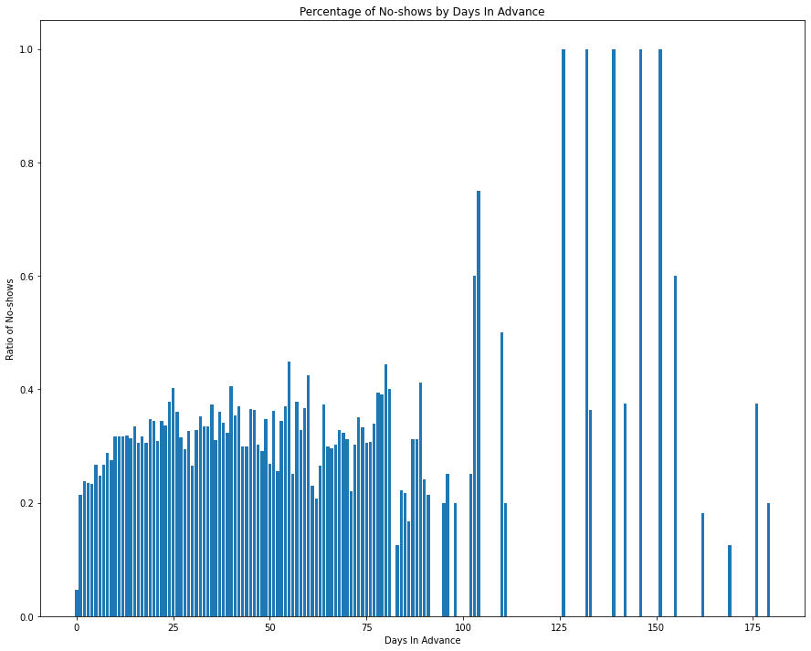

```python
data = df.groupby("DaysInAdvance")["No-show"].mean()
fig, ax = plt.subplots(figsize=(15,12))
ax.bar(x = data.index, height= list(data));
ax.set_xlabel("Days In Advance")
ax.set_ylabel("Ratio of No-shows")
ax.set_title("Percentage of No-shows by Days In Advance")
```

While this chart seems to show a correlation between `DaysInAdvance` and `No-show` it is likely skewed based on the amount of data available. Let's see a histogram of the distribution of data

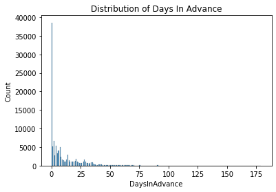

```python
ax = sns.histplot(data =df, x= "DaysInAdvance")
ax.set(title="Distribution of Days In Advance");
```

As suspected, there are very few data points past 75 `DaysInAdvance` so the data which shows that the 100% no-show percentage assosciated with larger `DaysInAdvance` values is due to insuficient data on that point. That being said, very few same day appointments were considered No-show. We should also see if a reminderer SMS had any impact on the attendance of patients.

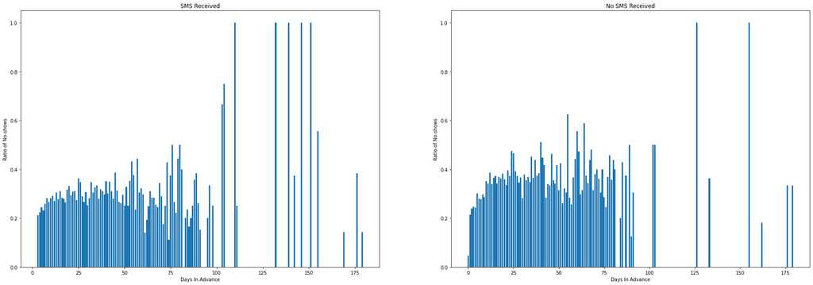

```python
sms_filter = df["SMS_received"] == 1
sms = df[sms_filter].groupby("DaysInAdvance")["No-show"].mean()
no_sms = df[~sms_filter].groupby("DaysInAdvance")["No-show"].mean()
fig, axes = plt.subplots(1,2, figsize=(30,10))
axes[0].bar(x = sms.index, height= list(sms))
axes[0].set_title('SMS Received')
axes[1].bar(x = no_sms.index, height= list(no_sms))
axes[1].set_title('No SMS Received')
for ax in axes:
  ax.set_xlabel("Days In Advance")
  ax.set_ylabel("Ratio of No-shows")
```

While the higher end of the data is still inconclusive, as there are not enough data points to go on, overall it appears that the group that received SMS messages had a lower No-show rate than those who did not.

### Does Location have any correlation with Percentage of No-shows?

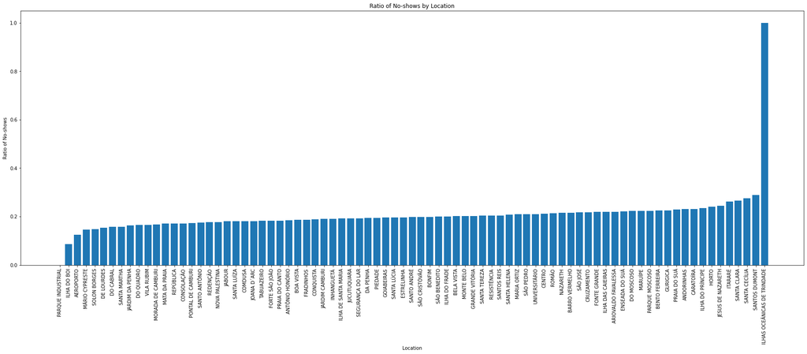

```python
data = df.groupby("Neighborhood")["No-show"].mean().sort_values()
fig, ax = plt.subplots(figsize=(30,10))
ax.bar(x = data.index, height= list(data));
ax.set_xlabel("Location")
ax.set_xticks(data.index, data.index ,rotation="vertical")
ax.set_ylabel("Ratio of No-shows")
ax.set_title("Ratio of No-shows by Location");
```

It seems like there are a couple of locations which have some interesting ratios of No-shows, specifically *ILHAS OCEÂNICAS DE TRINDADE* and *PARQUE INDUSTRIAL*. We should take a closer look at those two locations to ensure they aren't erroneous data.

```python
df[df["Neighborhood"].isin(["ILHAS OCEÂNICAS DE TRINDADE","PARQUE INDUSTRIAL"])]
```

|  | PatientId | AppointmentID | Gender | ScheduledDay | AppointmentDay | Age | Neighborhood | Scholarship | Hypertension | Diabetes | Alcoholism | Handicap | SMS_received | No-show | DaysInAdvance |
| --- | --- | --- | --- | --- | --- | --- | --- | --- | --- | --- | --- | --- | --- | --- | --- |
| 48754 | 534986855114.0 | 5583947 | F | 2016-04-14 | 2016-05-13 | 51 | ILHAS OCEÂNICAS DE TRINDADE | 0 | 0 | 0 | 0 | 0 | 0 | 1 | 29 |
| 48765 | 7256429752481.0 | 5583948 | F | 2016-04-14 | 2016-05-13 | 58 | ILHAS OCEÂNICAS DE TRINDADE | 0 | 0 | 0 | 0 | 0 | 0 | 1 | 29 |
| 75199 | 8255992453538.0 | 5663947 | F | 2016-05-05 | 2016-05-05 | 17 | PARQUE INDUSTRIAL | 0 | 0 | 0 | 0 | 0 | 0 | 0 | 0 |

Both cases are from a lack of data points and can be ruled out of any analysis on trends. Now we should look at the average age of patients at each location, sorted in the same way for ease of comparison

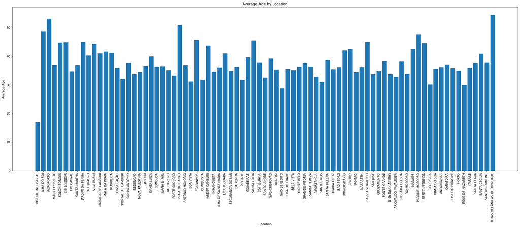

```python
data = df.groupby("Neighborhood")[["No-show", "Age"]].mean().sort_values("No-show")["Age"]
fig, ax = plt.subplots(figsize=(30,10))
ax.bar(x = data.index, height= list(data));
ax.set_xlabel("Location")
ax.set_xticks(data.index, data.index ,rotation="vertical")
ax.set_ylabel("Average Age");
ax.set_title("Average Age by Location");
```

It appears that average age doesn't have much impact on the no-show by location. We will check the age compared to no-show percentage to verify this finding.

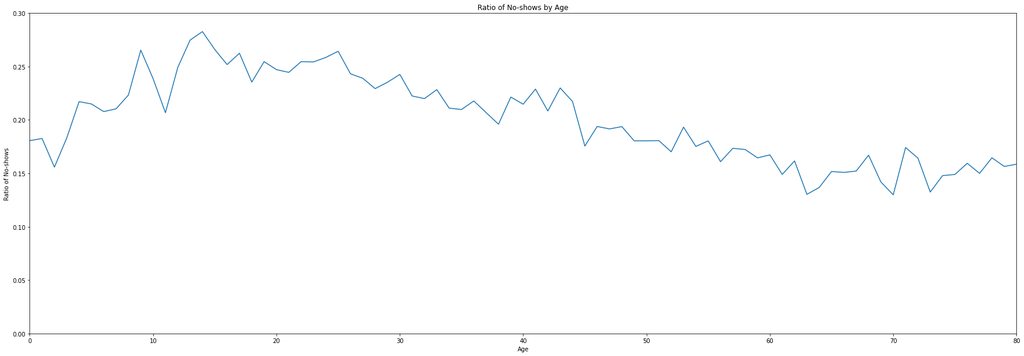

```python
data = df.groupby("Age")["No-show"].mean()
fig, ax = plt.subplots(figsize=(30,10))
ax = sns.lineplot(x = data.index, y= list(data));
ax.set_xlabel("Age")
ax.set_ylabel("Ratio of No-shows");
ax.set_ybound(0.0,1.0)
ax.set_title("Ratio of No-shows by Age")
plt.xlim(0,80)
plt.ylim(0,0.3);
```

## Conclusions

Overall we discovered useful correlations between `DaysInAdvance` and `SMS_received` and the percentage of `No-show` appointments. I would recommend using a CRM to automate sending SMS appointment reminders as well as attempting to schedule appointments as close to the `ScheduledDay` as possible to reduce some of the larger `DaysInAdvance` values as both of these practices have the potential to reduce the number of `No-show` appointments.

There are some limitations to this analysis. The data sample was limited and may not show an accurate assessment of certain areas or age groups, and more data would provide a more accurate result. Additionally, having additional features such as what kind of doctor patient's were seeing (ex: Cardiologist, Primary Care) would enable us to perform more complete analysis on patients likelyhood of attending their appointments.